# Naive Bayes for Flower Recognition

In this assignment, you will be asked to implement Gaussian Naive Bayes by yourself (sci-kit learn is not allowed) and use it classify what kind of iris flower the sample is given its features listed below:

1. sepal length in cm
2. sepal width in cm
3. petal length in cm
4. petal width in cm

There are three kinds of flowers: Iris Setosa, Iris Versicolour and Iris Virginica. The data we get comes from [Kaggle: Iris Dataset Visualization and Machine Learning](https://www.kaggle.com/xuhewen/iris-dataset-visualization-and-machine-learning). Make sure you have installed pandas, numpy and seaborn before running the script.

```
conda install pandas numpy seaborn
```

or

```
pip3 install pandas numpy seaborn
```

The following code loads the data and the dataset looks like the following:

```python
import pandas as pd
import numpy as np
import matplotlib.pyplot as plt
%matplotlib inline
from sklearn.utils import shuffle
iris = pd.read_csv('iris_data.txt', header=None) #read dataset
iris.columns = ['SepalLengthCm', 'SepalWidthCm', 'PetalLengthCm', 'PetalWidthCm', 'Species'] # rename each column
iris_visual = shuffle(iris, random_state = 0) # shuffle the dataset
iris_visual.head(10) #print the top ten entries
```

|  | SepalLengthCm | SepalWidthCm | PetalLengthCm | PetalWidthCm | Species |
| --- | --- | --- | --- | --- | --- |
| 114 | 5.8 | 2.8 | 5.1 | 2.4 | Iris-virginica |
| 62 | 6.0 | 2.2 | 4.0 | 1.0 | Iris-versicolor |
| 33 | 5.5 | 4.2 | 1.4 | 0.2 | Iris-setosa |
| 107 | 7.3 | 2.9 | 6.3 | 1.8 | Iris-virginica |
| 7 | 5.0 | 3.4 | 1.5 | 0.2 | Iris-setosa |
| 100 | 6.3 | 3.3 | 6.0 | 2.5 | Iris-virginica |
| 40 | 5.0 | 3.5 | 1.3 | 0.3 | Iris-setosa |
| 86 | 6.7 | 3.1 | 4.7 | 1.5 | Iris-versicolor |
| 76 | 6.8 | 2.8 | 4.8 | 1.4 | Iris-versicolor |
| 71 | 6.1 | 2.8 | 4.0 | 1.3 | Iris-versicolor |

```python
iris.info()
```

```
<class 'pandas.core.frame.DataFrame'>
RangeIndex: 150 entries, 0 to 149
Data columns (total 5 columns):
SepalLengthCm    150 non-null float64
SepalWidthCm     150 non-null float64
PetalLengthCm    150 non-null float64
PetalWidthCm     150 non-null float64
Species          150 non-null object
dtypes: float64(4), object(1)
memory usage: 6.0+ KB
```

## Visualization of the dataset.

The following code visualize the distribution of each pair of the features within each class. (Diagnals are probability density function for each feature).

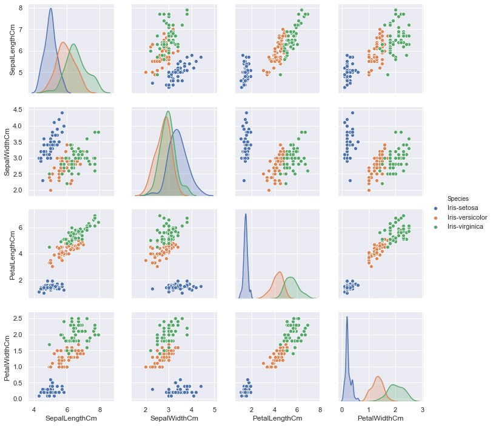

```python
import seaborn as sns
sns.set()
sns.pairplot(iris[['SepalLengthCm', 'SepalWidthCm', 'PetalLengthCm', 'PetalWidthCm', 'Species']],
             hue="Species", diag_kind="kde")
```

## Data splitting

Next, we split the data into training and testing sets according to 60/40 rule.

```python
from sklearn.model_selection import train_test_split

iris_data = np.array(iris)
X_trn, X_tst, y_trn, y_tst = train_test_split(iris_data[:,0:4], iris_data[:,4], test_size = 0.4, random_state = 0) # split the dataset into training and testing sets
```

# Problem 1 Write your own Gaussian Naive Bayes code

Using the skeleton provided below, write your own code for learning and inference using Gaussian Naive Bayes model. You can use the skeleton provided in the second problem to verify whether you are writing it correctly. Reading through chapter 1.9.1 in the following link and the slide from last year can be useful: https://scikit-learn.org/stable/modules/naive_bayes.html

https://www.dropbox.com/s/6d5h6fig1fj44e4/Naive_Bayes.pdf?dl=0

```python
import math

def gnb_train(X, y, output_label):
    output_size = len(output_label)
    prior = np.zeros(output_size)
    mean = np.zeros((output_size, X.shape[1]))
    std = np.zeros((output_size, X.shape[1]))
# ======= Your Code Here =======
    summation = 0
    variance = 0
    classOccurence = 0
    classCount = 0
    for i in range(0,output_size):
        # iterate over the jth index of element k
        for j in range(0,len(X[0])):
            for k in range(0,len(X)):
                if y[k] == output_label[i]:
                    summation+=X[k][j]
                    classOccurence+=1
            mean[i][j] = float(summation)/classOccurence
            for k in range(0,len(X)):
                if y[k] == output_label[i]:
                    variance += ((X[k][j]-float(summation)/classOccurence)**2)/classOccurence
            std[i][j] = (variance)**0.5
            summation = 0
            variance = 0
            classOccurence = 0
    # computing the prior
    for i in range(0,output_size):
        for j in range(0,len(y)):
            if y[j] == output_label[i]:
                classCount += 1
        prior[i] = classCount/len(y)
        classCount = 0
    return prior, mean, std

def gauss(x, mu, sigma):
    x = float(x - mu) / sigma
    return math.exp(-x*x/2.0) / (math.sqrt(2.0*math.pi) * sigma)

def gnb_predict(X, prior, mean, std, output_label):
    predict = []
    piproduct = 1
# ======= Your Code Here =======
    for i in range(0,len(X)):
        prob = [0]*len(output_label)
        for j in range(0,len(output_label)):
            priorp = prior[j]
            for k in range(0,len(X[0])):
                piproduct*=gauss(X[i][k],mean[j][k],std[j][k])
            prob[j] = priorp*piproduct
            piproduct = 1
        max_prob = max(prob)
        predict.append(output_label[prob.index(max_prob)])
        prob = [0]*len(output_label)
    return predict
```

# Problem 2: Inference on IRIS dataset

Using your own GNB functions, implementing Gaussian Naive Bayes algorithm for the first feature, the first two features, the first three features and the first four features. Output the error for each experiment and explain using the visualization of the dataset.

```python
from sklearn.metrics import hamming_loss
output_label = list(set(y_trn))
for i in range(1,5):
    prior, mean, std = gnb_train(X_trn[:,0:i], y_trn, output_label)
    y_pred = gnb_predict(X_tst[:,0:i], prior, mean, std, output_label)
    error = hamming_loss(y_tst, y_pred)
    print("Test error using first", i, "features:",  error)
```

```
Test error using first 1 features: 0.36666666666666664
Test error using first 2 features: 0.31666666666666665
Test error using first 3 features: 0.18333333333333332
Test error using first 4 features: 0.06666666666666667
```

### Problem 2 Explanation

As the number of features used increases from 1 to 4, we see a decrease in error from around 36.666% to only 6.666%. Based on the visualization of the dataset, we can see that for certain features, there can be a lot of overlap between the distribution of two labels, while other features are more clearly separable. By only using one feature, we are risking the potential for that feature to take on similar values for different labels. By using multiple features, we are making sure that one feature will not skew the probabilities. In addition, it is unlikely that two different labels will have the same distribution across all four features. By chaining the four features together, we are getting maximal separation.

### Problem 3: The Limitation of Naive Bayes

From the last feature, we can see the more features we use, we will get better performance. In this question, we show sometimes it is not the case. Repeat the first feature for $i = 1, 2, 3, ...., 300$ times and plot the testing error. Justify the plot. If we repeat the first feature for infinitely many number of times, will the test accuracy become zero? If yes, explain why and if not, what would be your guess for the final error?

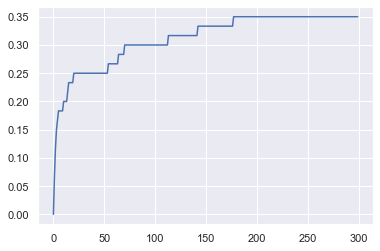

```python
err = np.zeros(300)
X_trn_new = np.hstack((X_trn, np.tile(X_trn[:, [0]], 20)))
for i in range(1,300):
    X_trn_new = np.hstack((X_trn, np.tile(X_trn[:, [0]], i)))
    X_tst_new = np.hstack((X_tst, np.tile(X_tst[:, [0]], i)))
    prior, mean, std = gnb_train(X_trn_new, y_trn, output_label)
    y_pred = gnb_predict(X_tst_new, prior, mean, std, output_label)
    err[i] = hamming_loss(y_tst, y_pred)
plt.plot(err)
```

### Question 3 Explanation

As we repeat the first feature more and more times, the error increases to a value of around 35% at i = 175. By repeating the first feature, we are assigning that feature to a higher weight. Thus, if the first feature has a slightly low probability, by giving it a higher weight, the overall probability is lowered even further. Thus, we expect the error to grow due to the increased weight on the first feature. Perhaps increasing the feature space by adding new features (not repeated ones) might be better. If we repeat the first feature for infinitely many times, I believe the testing accuracy will not be zero. I would guess that it would converge to around 30% to 40% based on the above plot for 300 repetitions.